# Cross-ancestry analysis of blood pressure GWASs

Published

June 23, 2023

## Outline

1. `organise_data.r` extracts Gill derived SBP regions from each population
2. Estimate Cochrane’s Q for each SNP across populations to identify any SNPs that have differential effects

Load organised data

```r
library(dplyr)
library(ggplot2)

ex <- readRDS("data/pop_extract_clumped.rds")
pops <- c("afr", "eas", "eur", "sas", "ugr")
```

How much signal is there amongst the different populations (i.e. what is the lowest p-value per population amongst the selected SNPs)

```r
ex %>%
    group_by(pop) %>%
    summarise(minp=min(pval), n=max(n, na.rm=T))
```

```
# A tibble: 5 × 3
  pop       minp     n
  <chr>    <dbl> <dbl>
1 afr   7.51e- 4  3725
2 eas   1.23e- 3  1506
3 eur   2.3 e-48  -Inf
4 sas   1.10e- 3  1302
5 ugr   5.67e- 4  6168
```

Not much signal beyond the European data.

Define heterogeneity test

```r
## Heterogeneity analysis
# TODO - allow
fixed_effects_meta_analysis <- function(beta_vec, se_vec) {
    w <- 1 / se_vec^2
    beta <- sum(beta_vec * w, na.rm=T) / sum(w, na.rm=T)
    se <- sqrt(1 / sum(w, na.rm=T))
    pval <- pnorm(abs(beta / se), lower.tail = FALSE)
    Qj <- w * (beta-beta_vec)^2
    Q <- sum(Qj, na.rm=T)
    Qdf <- sum(!is.na(beta_vec))-1
    if(Qdf == 0) Q <- 0
    Qjpval <- pchisq(Qj, 1, lower.tail=FALSE)
    Qpval <- pchisq(Q, Qdf, lower.tail=FALSE)
    return(list(beta=beta, se=se, Q=Q, Qdf=Qdf, Qpval=Qpval, Qj=Qj, Qjpval=Qjpval))
}

# check
# fixed_effects_meta_analysis(c(1,2,3), c(0.3, 0.3, 0.3))
# fixed_effects_meta_analysis(c(1,2,3), c(0.3, 0.3, 0.3))
# fixed_effects_meta_analysis(c(1,1,1), c(0.3, 0.3, 0.3))
# fixed_effects_meta_analysis(c(1,1,NA), c(0.3, 0.3, NA))

#' Test for heterogeneity of effect estimates between populations
#'
#' @description For each SNP this function will provide a Cochran's Q test statistic - a measure of heterogeneity of effect sizes between populations. A low p-value means high heterogeneity.
#' In addition, for every SNP it gives a per population p-value - this can be interpreted as asking for each SNP is a particular giving an outlier estimate.
#'
#' @param sslist Named list of data frames, one for each population, with at least beta, se and snp columns
#'
#' @return List
#' - Q = vector of p-values for Cochrane's Q statistic for each SNP
#' - Qj = Data frame of per-population outlier q values for each SNP
heterogeneity_test <- function(sslist) {
    j <- combine_data(sslist)
    b <- j %>% dplyr::select(starts_with("beta")) %>% as.matrix()
    se <- j %>% dplyr::select(starts_with("se")) %>% as.matrix()
    o <- lapply(1:nrow(b), \(i) {
        fixed_effects_meta_analysis(as.numeric(b[i,]), as.numeric(se[i,]))
    })
    Q <- tibble(snpid = j$snpid, Qpval = sapply(o, \(x) x$Qpval))
    Qj <- lapply(o, \(x) x$Qjpval) %>% do.call(rbind, .) %>%
        as_tibble()

    names(Qj) <- names(sslist)
    Qj$snpid <- j$snpid
    return(list(Q=Q, Qj=Qj))
}


combine_data <- function(sslist) {
    j <- sslist[[1]] %>% select(snpid, beta, se)
    for(i in 2:length(sslist))
    {
        j <- full_join(j, sslist[[i]] %>% select(snpid, beta, se), by="snpid")
    }
    j %>% dplyr::select(starts_with("beta"))
    return(j)
}
```

For each SNP that is present in at least 2 populations, estimate the heterogeneity of effects between the populations. Do this two ways

- `Q` - global heterogeneity test for the SNP across all populations (Cochrane’s Q)
- `Qj` - the deviation of each population contributing to the global heterogeneity Q

```r
exl <- lapply(pops, \(x) subset(ex, pop==x) %>% subset(!duplicated(snpid)))
names(exl) <- pops

o <- heterogeneity_test(exl)
o$Q$fdr <- p.adjust(o$Q$Qpval, "fdr")
min(o$Q$fdr)
```

```
[1] 0.7525778
```

Not much evidence for any heterogeneity. Plot the biggest heterogeneity SNPs (though none pass multiple testing)

```r
selsnpid <- subset(o$Q, Qpval < 0.05)$snpid
subset(o$Qj, snpid %in% selsnpid)
```

```
# A tibble: 13 × 6
       afr     eas   eur     sas       ugr snpid
     <dbl>   <dbl> <dbl>   <dbl>     <dbl> <chr>
 1 0.00658  0.482  0.878 0.353   NA        1:221326688_G_GT
 2 0.403    0.0724 0.611 0.0304   0.201    2:26912079_A_C
 3 0.804    0.652  0.729 0.00289  0.475    4:106911742_C_G
 4 0.108    0.0311 0.737 0.0801   0.308    5:32829975_C_G
 5 0.606    0.427  0.598 0.940    0.000954 6:31610384_C_T
 6 0.160    0.941  0.858 0.163    0.0138   7:75079683_A_G
 7 0.925    0.0154 0.878 0.0638   0.630    8:25900675_C_T
 8 0.485    0.0175 0.757 0.0941   0.0129   11:16373664_C_T
 9 0.157    0.276  0.763 0.0135  NA        11:122524741_A_G
10 0.00480  0.361  0.770 0.317    0.425    15:42266428_A_G
11 0.0130   0.426  0.611 0.0747   0.644    15:81025457_C_G
12 0.00173 NA      0.678 0.920    0.786    16:2089006_A_G
13 0.0829   0.0197 0.854 0.132    0.331    20:62447386_A_G
```

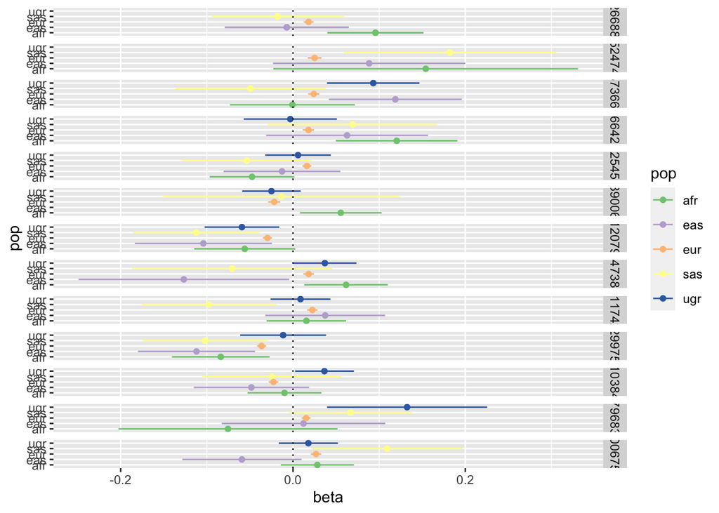

```r
ex %>%
    filter(snpid %in% selsnpid) %>%
    ggplot(., aes(x=beta, y=pop)) +
    geom_point(aes(colour=pop)) +
    geom_errorbarh(aes(colour=pop, xmin=beta-se*1.96, xmax=beta+se*1.96), height=0) +
    facet_grid(snpid ~ .) +
    geom_vline(xintercept=0, linetype="dotted") +
    scale_colour_brewer(type="qual")
```

Compare effects to see the degree of agreement of smaller pops vs European

```r
a <- subset(ex, pop=="eur")
b <- subset(ex, pop != "eur")
ab <- inner_join(a, b, by="snpid") %>% filter(pval.x < 5e-8)

nsum <- ex %>%
    group_by(pop) %>%
    summarise(minp=min(pval), n=max(n, na.rm=T)) %>%
    mutate(label = paste0(pop, ", n=", n))
ab <- left_join(ab, subset(nsum, select=c(pop, label)), by=c("pop.y"="pop"))

slope <- lapply(unique(ab$label), function(p){
    x <- subset(ab, label==p)
    summary(lm(beta.x ~ 0 + beta.y, data=x, weight=1/se.y^2))$coef %>% as_tibble()  %>%
    mutate(lab=paste0("b = ", round(Estimate, 2), " (", round(`Std. Error`, 3), ")"))
}) %>% bind_rows() %>% mutate(label=unique(ab$label))
slope
```

```
# A tibble: 4 × 6
  Estimate `Std. Error` `t value` `Pr(>|t|)` lab              label
     <dbl>        <dbl>     <dbl>      <dbl> <chr>            <chr>
1    0.296       0.0346      8.57   1.91e-15 b = 0.3 (0.035)  afr, n=3725
2    0.274       0.0259     10.6    2.11e-21 b = 0.27 (0.026) eas, n=1506
3    0.209       0.0255      8.22   1.46e-14 b = 0.21 (0.025) sas, n=1302
4    0.426       0.0548      7.77   2.46e-12 b = 0.43 (0.055) ugr, n=6168
```

The slopes are actually quite strong - plot

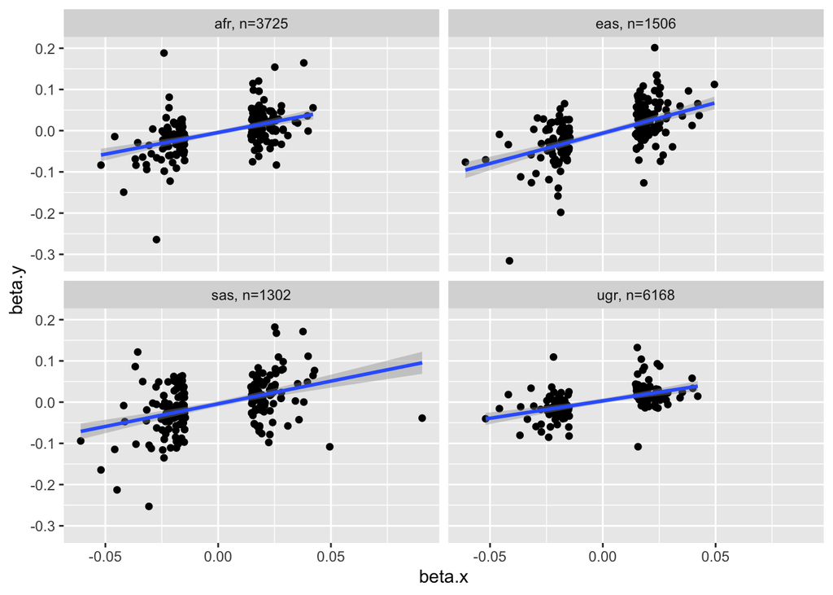

```r
ggplot(ab, aes(x=beta.x, y=beta.y)) +
geom_point() +
geom_smooth(method="lm") +
facet_wrap(~ label)
```

Compare the expected vs observed replication rates - European vs other populations

```r
## expected vs observed

#' Expected vs observed replication rates
#'
#' @description For a set of effects that have discovery and replication betas and SEs, this function determines the extent to which the observed replication rate matches the expected replication rate.
#' The expected replication rate is based on the assumption that the replication dataset has the same effect sizes but that the power may be different (e.g. due to allele frequencies or sample sizes) and is reflected in the replication standard errors.
#' It assesses replication based on concordance of effect direction across discovery and replication, and p-values surpassing a user-specified p-value threshold.
#'
#' @param b_disc vector of clumped incidence hit effects
#' @param se_disc the standard errors for incidence effects
#' @param b_rep corresponding vector of associations in progression
#' @param se_rep standard errors of effects in progression
#' @param alpha p-value threshold to check for replication of incidence hits in progression (e.g. try 0.05 or 1e-5)
expected_vs_observed_replication <- function(b_disc, b_rep, se_disc, se_rep, alpha) {
    p_sign <- pnorm(-abs(b_disc) / se_disc) * pnorm(-abs(b_disc) / se_rep) + ((1 - pnorm(-abs(b_disc) / se_disc)) * (1 - pnorm(-abs(b_disc) / se_rep)))
    p_sig <- pnorm(-abs(b_disc) / se_rep + qnorm(alpha / 2)) + (1 - pnorm(-abs(b_disc) / se_rep - qnorm(alpha / 2)))
    p_rep <- pnorm(abs(b_rep)/se_rep, lower.tail=FALSE)
    res <- tibble::tibble(
        nsnp=length(b_disc),
        metric=c("Sign", "Sign", "P-value", "P-value"),
        datum=c("Expected", "Observed", "Expected", "Observed"),
        value=c(sum(p_sign, na.rm=TRUE), sum(sign(b_disc) == sign(b_rep)), sum(p_sig, na.rm=TRUE), sum(p_rep < alpha, na.rm=TRUE)),
        pdiff=c(NA_real_, binom.test(value[2], nsnp[2], value[1]/nsnp[2])$p.value, NA_real_, binom.test(value[4], nsnp[4], value[3]/nsnp[4])$p.value)
    )
    res_per_variant <- tibble(
        expected_pval = p_sig,
        observed_pval = p_rep < alpha,
        replication_fail = expected_pval > 0.95 & ! observed_pval,
        expected_sign = p_sign,
        observed_sign = sign(b_disc) == sign(b_rep),
        sign_fail = expected_sign > 0.95 & ! observed_sign
    )
    return(list(res=res, variants=res_per_variant))
}


eores <- lapply(unique(ab$pop.y), function(p){
    x <- subset(ab, pop.y==p)
    o <- expected_vs_observed_replication(x$beta.x, x$beta.y, x$se.x, x$se.y, 0.01)
    o$res$pop <- p
    o$variants$pop <- p
    return(o)
})

lapply(eores, \(x) x$res) %>% bind_rows() %>% subset(metric=="Sign") %>% dplyr::select(pop, nsnp, datum, value, pdiff)
```

```
# A tibble: 8 × 5
  pop    nsnp datum    value   pdiff
  <chr> <int> <chr>    <dbl>   <dbl>
1 afr     218 Expected  162. NA
2 afr     218 Observed  151   0.0868
3 eas     218 Expected  149. NA
4 eas     218 Observed  152   0.663
5 sas     232 Expected  158. NA
6 sas     232 Observed  169   0.139
7 ugr     126 Expected  102. NA
8 ugr     126 Observed   96   0.215
```

The degree of replication of the beta direction is in line with expectation across all populations

```r
lapply(eores, \(x) x$res) %>% bind_rows() %>% subset(metric=="P-value") %>% dplyr::select(pop, nsnp, datum, value, pdiff)
```

```
# A tibble: 8 × 5
  pop    nsnp datum    value    pdiff
  <chr> <int> <chr>    <dbl>    <dbl>
1 afr     218 Expected  7.51 NA
2 afr     218 Observed 12     0.0950
3 eas     218 Expected  4.91 NA
4 eas     218 Observed  7     0.352
5 sas     232 Expected  4.78 NA
6 sas     232 Observed 11     0.00935
7 ugr     126 Expected  7.53 NA
8 ugr     126 Observed  9     0.570
```

The degree of replication of the p-value is slightly higher than expected - this is because of ascertainment from the meta analysis.